# Thyroid Detection EDA and ML model

#### Exploratory Data Analysis

```python
import pandas as pd
import numpy as np
from matplotlib import pyplot as plt
import seaborn as sns
```

```python
data = pd.read_csv('thyroid.csv')
data.head()
```

|  | age | sex | on_thyroxine | query_on_thyroxine | on_antithyroid_medication | sick | pregnant | thyroid_surgery | I131_treatment | query_hypothyroid | ... | TT4_measured | TT4 | T4U_measured | T4U | FTI_measured | FTI | TBG_measured | TBG | referral_source | Class |
| --- | --- | --- | --- | --- | --- | --- | --- | --- | --- | --- | --- | --- | --- | --- | --- | --- | --- | --- | --- | --- | --- |
| 0 | 41 | F | f | f | f | f | f | f | f | f | ... | t | 125 | t | 1.14 | t | 109 | f | ? | SVHC | negative |
| 1 | 23 | F | f | f | f | f | f | f | f | f | ... | t | 102 | f | ? | f | ? | f | ? | other | negative |
| 2 | 46 | M | f | f | f | f | f | f | f | f | ... | t | 109 | t | 0.91 | t | 120 | f | ? | other | negative |
| 3 | 70 | F | t | f | f | f | f | f | f | f | ... | t | 175 | f | ? | f | ? | f | ? | other | negative |
| 4 | 70 | F | f | f | f | f | f | f | f | f | ... | t | 61 | t | 0.87 | t | 70 | f | ? | SVI | negative |

5 rows × 30 columns

#### Description about the features in the dataset:

1. **age** - Shows the age of the patient.
2. **sex** - Shows the gender of the patient.
3. **on_thyroxine** - Shows whether the patient is on Thyroxine treatment or not.
4. **query_on_thyroxine** - Shows whether the patient has raised any queries regarding their thyroxine treatment/hormone or not.
5. **on_antithyroid_medication** - Shows whether the patient is on antithyroid_medication or not.
6. **sick** - Shows whether the patient is sick or not.
7. **pregnant** - Shows whether the patient is pregnant or not.
8. **thyroid_surgery** - Shows whether the patient has gone through Thyroid surgery or not
9. **I131_treatment** - Shows whether the patient is going through Radioactive Iodine(I-131) treatment or not.
10. **query_hypothyroid** - Shows whether the patient has raised any query regarding hypothyroid or not. Hypothyroid means thyroid is less than the optimum amounts.
11. **query_hyperthyroid** - Shows whether the patient has raised any query regarding hyperthyroid or not. Hyperthyroid means thyroid is more than the optimum amounts.
12. **lithium** - Shows whether the patient is on Lithium treatment or not.
13. **goitre** - Shows whether the patient is suffering from Goitre or not.
14. **tumor** - Shows whether the patient has any tumor or not. Tumor can either be benign or malignant.
15. **hypopituitary** - Shows whether the patient is on hypopituitary gland related treatment or not.
16. **psych** - Shows the patient's psych evaluation.
17. **TSH_measured** - Shows whether the thyroid stimulating hormone(TSH) has been measured or not.
18. **TSH** - If TSH has been measured then this columm shows the value of the TSH.
19. **T3_measured** - T3 is one of two major hormones made by your thyroid. Shows whether T3 of the patient has been measured or not.
20. **T3** - If T3 has been measured then this columm shows the value of the T3.
21. **TT4_measured** - T4 is another one of two major hormones made by your thyroid. Shows whether T4 of the patient has been measured or not.
22. **TT4** - If T3 has been measured then this columm shows the value of the T4.
23. **T4U_measured** - Shows whether T4U has been measured or not.
24. **T4U** - If measured, the value of the same.
25. **FTI_measured** - Shows Whether FTI(Free Thyroxine Index) for the patient has been measured or not.
26. **FTI** - If FTI has been measured then this columm shows the value of the FTI.
27. **TBG_measured** - Shows whether Thyroxine-Binding Globulin Deficiency has been measured or not.
28. **TBG** - If TBG is measured then it shows value of the same.
29. **referral_source** - Shows the organization/hospital from where the patient has been refferred.
30. **Class** - This is the Dependent feature. It consists of 4 classes 'negative', 'compensated hypothoroid', 'primary hypothoroid', 'secondary hypothoroid'.

#### Checking for missin values:

```python
data.isnull().sum().mean()
```

```
0.0
```

#### Int his dataset, f for every colum means False and t means True.

#### Here in this dataset, all missing values are question marks '?'. These are the values where the corresponding measurement is False.

```python
data.shape
```

```
(3772, 30)
```

```python
# plt.figure(figsize=(10,10))
# df['sorted_age'] = df.age.sort_values(ascending=True)
# plt.scatter(df['sorted_age'],df['Class'])
# plt.show()
# df.drop('sorted_age',axis=1,inplace=True)
```

```python
for feature in data:
    count = data[feature][data[feature] == '?'].count()
    if count != 0:
        print(feature,count)
```

```
age 1
sex 150
TSH 369
T3 769
TT4 231
T4U 387
FTI 385
TBG 3772
```

#### Converting all '?' to np.NaNs:

```python
for feature in data:
    count = data[feature][data[feature] == '?'].count()
    if count != 0:
        data[feature] = data[feature].replace('?',np.NaN)
```

#### Checking for '?' again for verification:

```python
for feature in data:
    count = data[feature][data[feature] == '?'].count()
    if count == 0:
        print(feature,count)
```

```
age 0
sex 0
on_thyroxine 0
query_on_thyroxine 0
on_antithyroid_medication 0
sick 0
pregnant 0
thyroid_surgery 0
I131_treatment 0
query_hypothyroid 0
query_hyperthyroid 0
lithium 0
goitre 0
tumor 0
hypopituitary 0
psych 0
TSH_measured 0
TSH 0
T3_measured 0
T3 0
TT4_measured 0
TT4 0
T4U_measured 0
T4U 0
FTI_measured 0
FTI 0
TBG_measured 0
TBG 0
referral_source 0
Class 0
```

```python
data.isnull().sum()
```

```
age                             1
sex                           150
on_thyroxine                    0
query_on_thyroxine              0
on_antithyroid_medication       0
sick                            0
pregnant                        0
thyroid_surgery                 0
I131_treatment                  0
query_hypothyroid               0
query_hyperthyroid              0
lithium                         0
goitre                          0
tumor                           0
hypopituitary                   0
psych                           0
TSH_measured                    0
TSH                           369
T3_measured                     0
T3                            769
TT4_measured                    0
TT4                           231
T4U_measured                    0
T4U                           387
FTI_measured                    0
FTI                           385
TBG_measured                    0
TBG                          3772
referral_source                 0
Class                           0
dtype: int64
```

#### Now, we have proper missing values in the dataset as NaN. We have categorical and numerical features in the dataset. We will handle missing values for the numerical features. Also we should drop all 'measured' columns as these have no direct impact on the dataset as well as column 'TBG' should be removed as it has all missing values. Also 'referral source' should have no affect on Thyroid class.

```python
# Removing the unnecessary columns
data.drop(columns=['TSH_measured','T3_measured','TT4_measured','T4U_measured','FTI_measured','TBG_measured','referral_source','TBG'],axis=1,inplace=True)
```

#### Converting categorical features to numbers:

```python
data['sex'].unique()
```

```
array(['F', 'M', nan], dtype=object)
```

```python
data['sex']= data['sex'].map({'F':0,'M':1})
```

```python
for feature in data:
    if len(data[feature].unique()) == 2:
        data[feature] = data[feature].map({'f':0,'t':1})
```

```python
# Our Class feature has many labels:
df['Class'].unique()
```

```
array(['negative', 'compensated_hypothyroid', 'primary_hypothyroid',
       'secondary_hypothyroid'], dtype=object)
```

```python
# Therefore, we will now labelencode the data.
from sklearn.preprocessing import LabelEncoder
lbEn = LabelEncoder()
df['Class'] = lbEn.fit_transform(df["Class"])
```

#### Our categorical features have now been convrted to numbers. Now we will impute missing values using median imputation.

```python
# Handling missing values for numerical features using median imputation:
columns = ['age','sex','TSH','T3','TT4','FTI','T4U']
for feature in columns:
    median = data[feature].median()
    data[feature] = data[feature].fillna(median)
```

```python
data.head()
```

|  | age | sex | on_thyroxine | query_on_thyroxine | on_antithyroid_medication | sick | pregnant | thyroid_surgery | I131_treatment | query_hypothyroid | ... | goitre | tumor | hypopituitary | psych | TSH | T3 | TT4 | T4U | FTI | Class |
| --- | --- | --- | --- | --- | --- | --- | --- | --- | --- | --- | --- | --- | --- | --- | --- | --- | --- | --- | --- | --- | --- |
| 0 | 41.0 | 0.0 | 0.0 | 0.0 | 0.0 | 0.0 | 0.0 | 0.0 | 0.0 | 0.0 | ... | 0.0 | 0.0 | 0.0 | 0.0 | 1.0 | 2.0 | 125.0 | 1.0 | 109.0 | 1.0 |
| 1 | 23.0 | 0.0 | 0.0 | 0.0 | 0.0 | 0.0 | 0.0 | 0.0 | 0.0 | 0.0 | ... | 0.0 | 0.0 | 0.0 | 0.0 | 4.0 | 2.0 | 102.0 | 1.0 | 108.0 | 1.0 |
| 2 | 46.0 | 1.0 | 0.0 | 0.0 | 0.0 | 0.0 | 0.0 | 0.0 | 0.0 | 0.0 | ... | 0.0 | 0.0 | 0.0 | 0.0 | 1.0 | 2.0 | 109.0 | 1.0 | 120.0 | 1.0 |
| 3 | 70.0 | 0.0 | 1.0 | 0.0 | 0.0 | 0.0 | 0.0 | 0.0 | 0.0 | 0.0 | ... | 0.0 | 0.0 | 0.0 | 0.0 | 0.0 | 2.0 | 175.0 | 1.0 | 177.0 | 1.0 |
| 4 | 70.0 | 0.0 | 0.0 | 0.0 | 0.0 | 0.0 | 0.0 | 0.0 | 0.0 | 0.0 | ... | 0.0 | 0.0 | 0.0 | 0.0 | 1.0 | 1.0 | 61.0 | 1.0 | 70.0 | 1.0 |

5 rows × 22 columns

```python
data.isnull().sum()
```

```
age                          0
sex                          0
on_thyroxine                 0
query_on_thyroxine           0
on_antithyroid_medication    0
sick                         0
pregnant                     0
thyroid_surgery              0
I131_treatment               0
query_hypothyroid            0
query_hyperthyroid           0
lithium                      0
goitre                       0
tumor                        0
hypopituitary                0
psych                        0
TSH                          0
T3                           0
TT4                          0
T4U                          0
FTI                          0
Class                        0
dtype: int64
```

#### As we can see the entire data is now numerical and all missing values have been handled effectively.

#### Now, let's look at the distributions of various features:

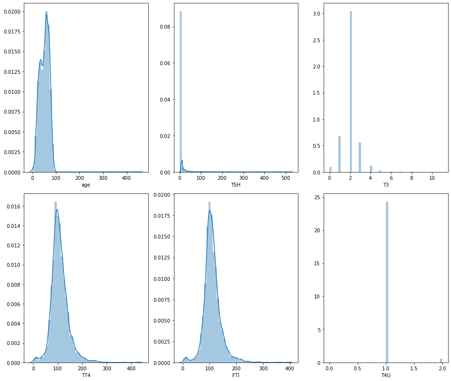

```python
columns = ['age','TSH','T3','TT4','FTI','T4U']
plt.figure(figsize=(13,11))
plotnumber = 1
for feature in columns:
    ax = plt.subplot(2,3,plotnumber)
    sns.distplot(data[feature])
    plt.xlabel(feature)
    plotnumber+=1
plt.tight_layout()
```

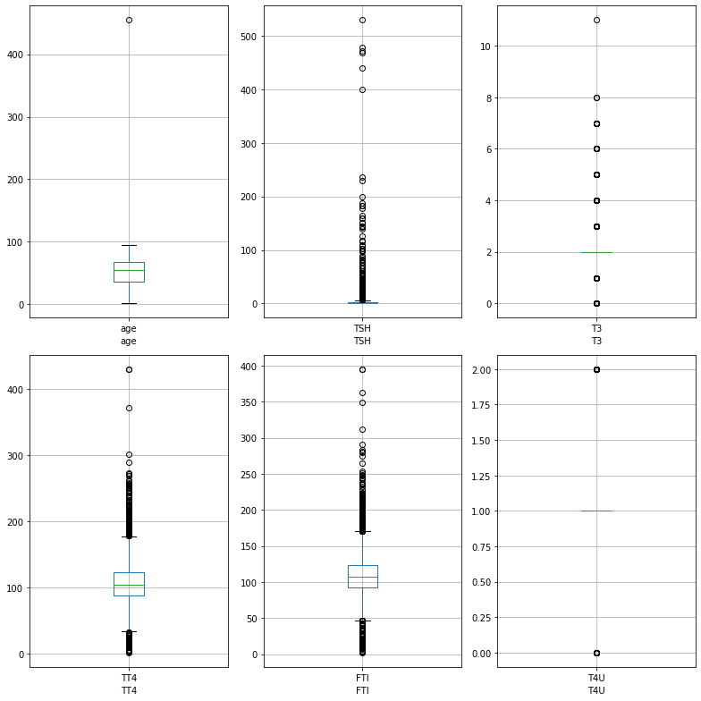

```python
plt.figure(figsize=(11,11))
columns = ['age','TSH','T3','TT4','FTI','T4U']
plotnumber = 1
for feature in columns:
    ax = plt.subplot(2,3,plotnumber)
    data.boxplot(column=feature)
    plt.xlabel(feature)
    plotnumber += 1
plt.tight_layout()
```

#### Since all features are not having Gaussian distribution, we will transform these features. We will do this plotting Q-Q plots for various transformations.

```python
# Now we have some which features which are skewed and 3 of the features do not have bormal distribution
# Let's work with Q-Q plots to check the scaling that we can apply:
import scipy.stats as stat
import pylab
def plot_QQ(df,feature_1,feature_2,feature_3,feature_4,feature_5):
    plt.figure(figsize=(10,10))#probplot is Q-Q plot
    plt.subplot(3,3,1)  #3 rows, 3 columns, 1st placement
    sns.distplot(df[feature_1])
    stat.probplot(df[feature_1],dist='norm',plot=pylab)
    plt.xlabel(feature_1)
    plt.subplot(3,3,2)
    stat.probplot(df[feature_2],dist='norm',plot=pylab)
    plt.xlabel(feature_2)
    plt.subplot(3,3,3)
    stat.probplot(df[feature_3],dist='norm',plot=pylab)
    plt.xlabel(feature_3)
    plt.subplot(3,3,7)
    stat.probplot(df[feature_4],dist='norm',plot=pylab)
    plt.xlabel(feature_4)
    plt.subplot(3,3,8)
    stat.probplot(df[feature_5],dist='norm',plot=pylab)
    plt.xlabel(feature_5)
    plt.show()
```

```python
# Creating a function which creates new features and applies logarithmic , reciprocal, square root and
# exponential transformations to the same.
dataframe = data.copy()
def transform_feat(dataframe,feature):
    dataframe[feature+'_log'] = np.log(dataframe[feature])
    dataframe[feature+'_reciprocal'] = 1/dataframe[feature]
    dataframe[feature+'_sqrt'] = np.sqrt(dataframe[feature])
    dataframe[feature+'_exp'] = dataframe[feature]**(1/1.2)
```

```python
transform_feat(dataframe,'age')
```

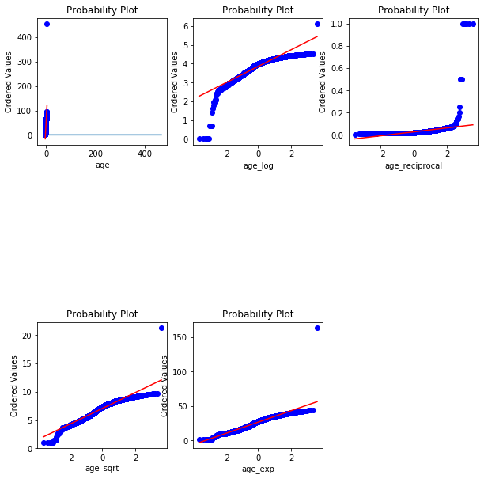

```python
plot_QQ(dataframe,'age','age_log','age_reciprocal','age_sqrt','age_exp')
```

```python
transform_feat(dataframe,'TSH')
```

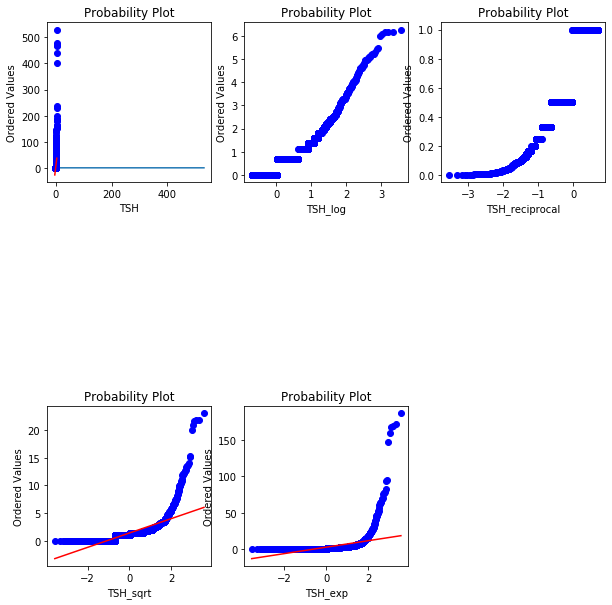

```python
plot_QQ(dataframe,'TSH','TSH_log','TSH_reciprocal','TSH_sqrt','TSH_exp')
```

```python
transform_feat(dataframe,'T3')
```

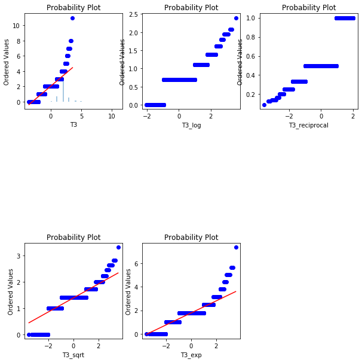

```python
plot_QQ(dataframe,'T3','T3_log','T3_reciprocal','T3_sqrt','T3_exp')
```

```python
transform_feat(dataframe,'TT4')
```

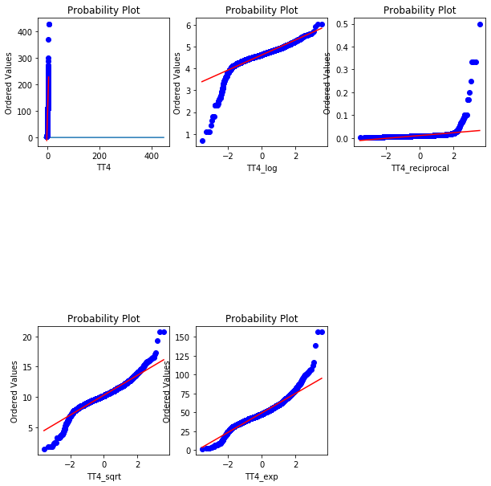

```python
plot_QQ(dataframe,'TT4','TT4_log','TT4_reciprocal','TT4_sqrt','TT4_exp')
```

```python
transform_feat(dataframe,'FTI')
```

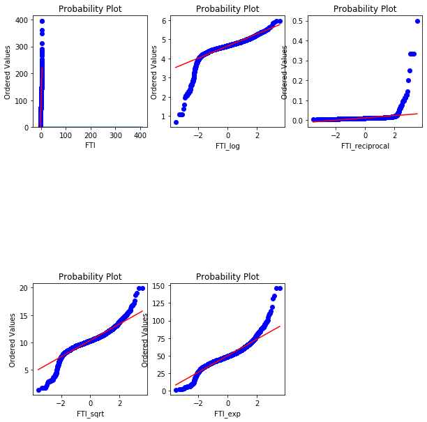

```python
plot_QQ(dataframe,'FTI','FTI_log','FTI_reciprocal','FTI_sqrt','FTI_exp')
```

```python
transform_feat(dataframe,'T4U')
```

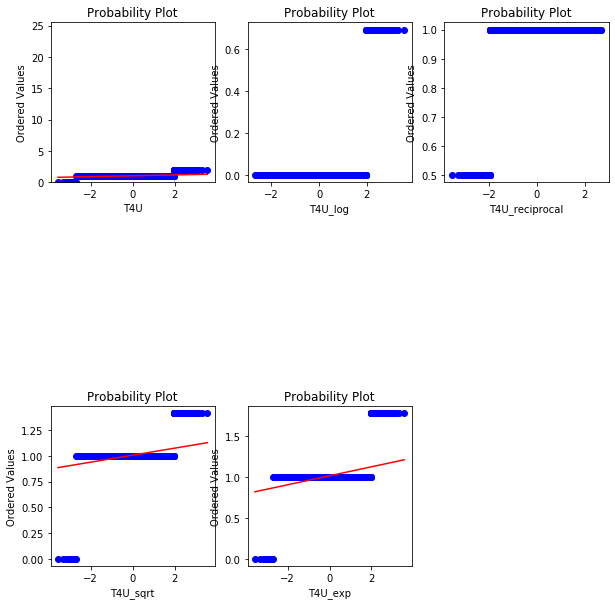

```python
plot_QQ(dataframe,'T4U','T4U_log','T4U_reciprocal','T4U_sqrt','T4U_exp')
```

#### As we can clearly see that various transformations are iving different Q-Q plots. So we are going to check with various transformations.

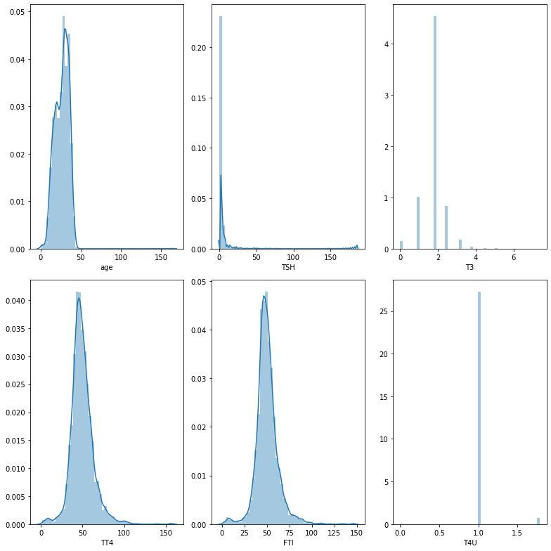

```python
# checking with exponential:
plt.figure(figsize=(11,11))
columns = ['age','TSH','T3','TT4','FTI','T4U']
plotnumber = 1
for feature in columns:
    ax = plt.subplot(2,3,plotnumber)
    data[feature] = data[feature]**(1/1.2)
    sns.distplot(data[feature])
    plt.xlabel(feature)
    plotnumber+=1
plt.tight_layout()
```

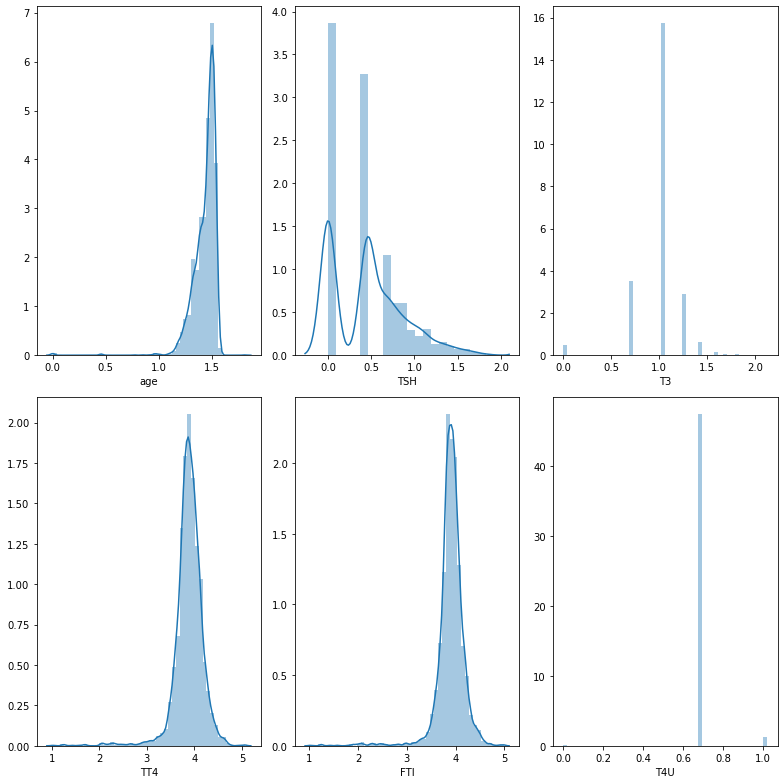

```python
# checking with logarithmic transformation:
plt.figure(figsize=(11,11))
columns = ['age','TSH','T3','TT4','FTI','T4U']
plotnumber = 1
for feature in columns:
    ax = plt.subplot(2,3,plotnumber)
    data[feature] = np.log(data[feature]+1)
    sns.distplot(data[feature])
    plt.xlabel(feature)
    plotnumber+=1
plt.tight_layout()
```

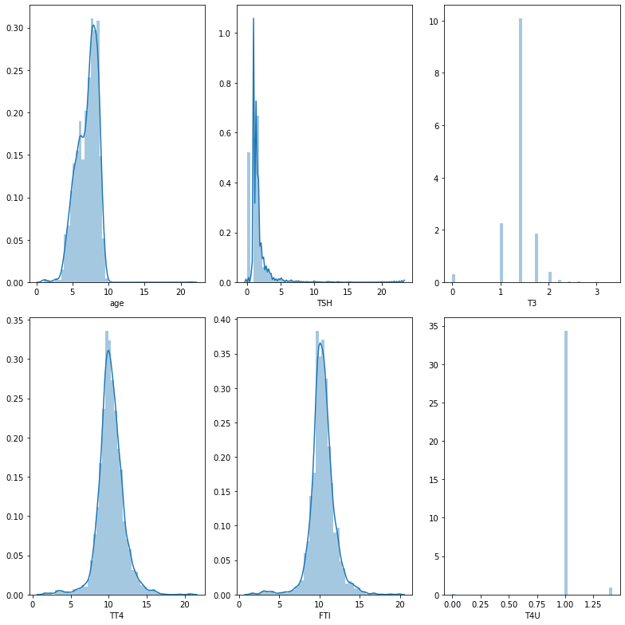

```python
# checking with square root transformation:
plt.figure(figsize=(11,11))
columns = ['age','TSH','T3','TT4','FTI','T4U']
plotnumber = 1
for feature in columns:
    ax = plt.subplot(2,3,plotnumber)
    data[feature] = np.sqrt(data[feature])
    sns.distplot(data[feature])
    plt.xlabel(feature)
    plotnumber+=1
plt.tight_layout()
```

```python
data.drop(columns=['TSH'],axis=1,inplace=True)
```

```python
# Transforming the features using logarithmic transformation
columns = ['age','T3','TT4','FTI','T4U']

for feature in columns:
    data[feature] = np.log(data[feature]+1)
```

```python
data.head()
```

|  | age | sex | on_thyroxine | query_on_thyroxine | on_antithyroid_medication | sick | pregnant | thyroid_surgery | I131_treatment | query_hypothyroid | ... | lithium | goitre | tumor | hypopituitary | psych | T3 | TT4 | T4U | FTI | Class |
| --- | --- | --- | --- | --- | --- | --- | --- | --- | --- | --- | --- | --- | --- | --- | --- | --- | --- | --- | --- | --- | --- |
| 0 | 3.737670 | 0.0 | 0.0 | 0.0 | 0.0 | 0.0 | 0.0 | 0.0 | 0.0 | 0.0 | ... | 0.0 | 0.0 | 0.0 | 0.0 | 0.0 | 1.098612 | 4.836282 | 0.693147 | 4.700480 | 1.0 |
| 1 | 3.178054 | 0.0 | 0.0 | 0.0 | 0.0 | 0.0 | 0.0 | 0.0 | 0.0 | 0.0 | ... | 0.0 | 0.0 | 0.0 | 0.0 | 0.0 | 1.098612 | 4.634729 | 0.693147 | 4.691348 | 1.0 |
| 2 | 3.850148 | 1.0 | 0.0 | 0.0 | 0.0 | 0.0 | 0.0 | 0.0 | 0.0 | 0.0 | ... | 0.0 | 0.0 | 0.0 | 0.0 | 0.0 | 1.098612 | 4.700480 | 0.693147 | 4.795791 | 1.0 |
| 3 | 4.262680 | 0.0 | 1.0 | 0.0 | 0.0 | 0.0 | 0.0 | 0.0 | 0.0 | 0.0 | ... | 0.0 | 0.0 | 0.0 | 0.0 | 0.0 | 1.098612 | 5.170484 | 0.693147 | 5.181784 | 1.0 |
| 4 | 4.262680 | 0.0 | 0.0 | 0.0 | 0.0 | 0.0 | 0.0 | 0.0 | 0.0 | 0.0 | ... | 0.0 | 0.0 | 0.0 | 0.0 | 0.0 | 0.693147 | 4.127134 | 0.693147 | 4.262680 | 1.0 |

5 rows × 21 columns

#### Checking for correlation:

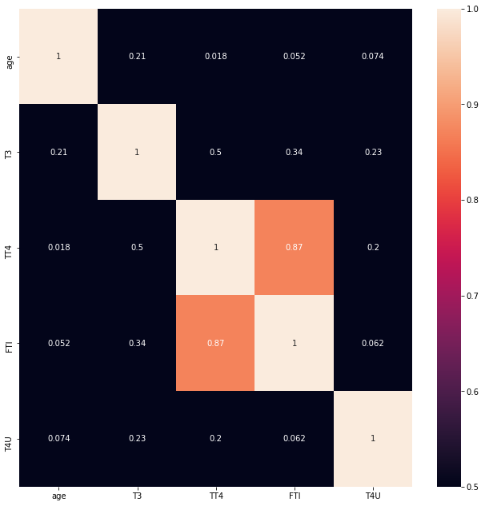

```python
data_2 = data[['age','T3','TT4','FTI','T4U']]
plt.figure(figsize=(11,11))
sns.heatmap(data_2.corr().abs(),vmin=0.5,vmax=1,annot=True)
```

#### Now, we need to check whether the Class is balanced or unbalanced:

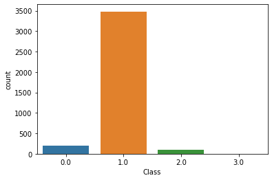

```python
sns.countplot(data['Class'])
```

#### As we can clearly see that this datset is clearly unbalanced. No, we are going to balance this dataset:

```python
from imblearn.over_sampling import RandomOverSampler
```

```python
X = data.drop('Class',axis=1)
y = data['Class']
```

```python
rdsample = RandomOverSampler()
X_sampled, y_sampled = rdsample.fit_sample(X,y)
```

```python
X_sampled.shape
```

```
(13924, 20)
```

```python
X_sampled = pd.DataFrame(data=X_sampled,columns=X.columns)
```

```python
X_sampled.head()
```

|  | age | sex | on_thyroxine | query_on_thyroxine | on_antithyroid_medication | sick | pregnant | thyroid_surgery | I131_treatment | query_hypothyroid | query_hyperthyroid | lithium | goitre | tumor | hypopituitary | psych | T3 | TT4 | T4U | FTI |
| --- | --- | --- | --- | --- | --- | --- | --- | --- | --- | --- | --- | --- | --- | --- | --- | --- | --- | --- | --- | --- |
| 0 | 3.737670 | 0.0 | 0.0 | 0.0 | 0.0 | 0.0 | 0.0 | 0.0 | 0.0 | 0.0 | 0.0 | 0.0 | 0.0 | 0.0 | 0.0 | 0.0 | 1.098612 | 4.836282 | 0.693147 | 4.700480 |
| 1 | 3.178054 | 0.0 | 0.0 | 0.0 | 0.0 | 0.0 | 0.0 | 0.0 | 0.0 | 0.0 | 0.0 | 0.0 | 0.0 | 0.0 | 0.0 | 0.0 | 1.098612 | 4.634729 | 0.693147 | 4.691348 |
| 2 | 3.850148 | 1.0 | 0.0 | 0.0 | 0.0 | 0.0 | 0.0 | 0.0 | 0.0 | 0.0 | 0.0 | 0.0 | 0.0 | 0.0 | 0.0 | 0.0 | 1.098612 | 4.700480 | 0.693147 | 4.795791 |
| 3 | 4.262680 | 0.0 | 1.0 | 0.0 | 0.0 | 0.0 | 0.0 | 0.0 | 0.0 | 0.0 | 0.0 | 0.0 | 0.0 | 0.0 | 0.0 | 0.0 | 1.098612 | 5.170484 | 0.693147 | 5.181784 |
| 4 | 4.262680 | 0.0 | 0.0 | 0.0 | 0.0 | 0.0 | 0.0 | 0.0 | 0.0 | 0.0 | 0.0 | 0.0 | 0.0 | 0.0 | 0.0 | 0.0 | 0.693147 | 4.127134 | 0.693147 | 4.262680 |

#### Let us look at the Class data now:

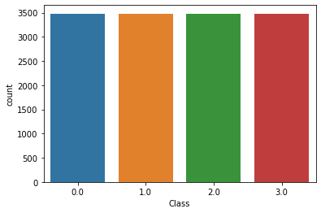

```python
sns.countplot(y_sampled)
plt.show()
```

#### As we can see that our data is balanced right now. This same data can be used for building ML models.This completes the EDA and Feature engineering for the dataset.

### ML Model building

#### Train Test Split:

```python
from sklearn.model_selection import train_test_split
```

```python
X_train,X_test,y_train,y_test = train_test_split(X_sampled,y_sampled,test_size=0.3,random_state=0)
```

#### Let's check with multiple ML models:

#### Logistic Regression:

```python
from sklearn.metrics import roc_curve
from sklearn.metrics import roc_auc_score
from sklearn.metrics import accuracy_score
```

```python
from sklearn.linear_model import LogisticRegression
from sklearn.multiclass import OneVsRestClassifier
import time
```

```python
lr = LogisticRegression(multi_class='ovr',random_state=42,max_iter=1000)
start = time.time()
lr.fit(X_train,y_train)
stop = time.time()
print(f"Training time: {stop - start}s")
```

```
Training time: 2.2925074100494385s
```

```python
ytrain_pred = lr.predict_proba(X_train)
if len(y_train.unique()) == 1:
    train_score = accuracy_score(y_train,ytrain_pred)
    cm = confusion_matrix(y_train,ytrain_pred)
    cr = classification_report(y_train,ytrain_pred)
    print(f' Training Score: {train_score},{cr}')
else:
    roc_auc = roc_auc_score(y_train,ytrain_pred,multi_class='ovr')
    print(f' Training roc_auc score:{roc_auc}')
```

```
 Training roc_auc score:0.9290583715859491
```

```python
y_pred = lr.predict_proba(X_test)
if len(y_test.unique()) == 1:
    test_score = accuracy_score(y_test,y_pred)
    cm = confusion_matrix(y_test,y_pred)
    cr = classification_report(y_test,y_pred)
    print(f' Test Score: {train_score},{cr}')
else:
    roc_auc = roc_auc_score(y_test,y_pred,multi_class='ovr')
    print(f' Test roc_auc score:{roc_auc}')
```

```
 Test roc_auc score:0.9315616398938442
```

```python
from sklearn.metrics import confusion_matrix
cm_lr = confusion_matrix()
```

#### Support vector Machines:

```python
from sklearn.svm import SVC
```

```python
svc = SVC(random_state=0,probability=True,decision_function_shape='ovo')
start = time.time()
svc.fit(X_train,y_train)
stop = time.time()
print(f"Training time: {stop - start}s")
```

```
Training time: 13.904470443725586s
```

```python
ytrain_pred = svc.predict_proba(X_train)
if len(y_train.unique()) == 1:
    train_score = accuracy_score(y_train,ytrain_pred)
    cm = confusion_matrix(y_train,ytrain_pred)
    cr = classification_report(y_train,ytrain_pred)
    print(f' Training Score: {train_score},{cr}')
else:
    roc_auc = roc_auc_score(y_train,ytrain_pred,multi_class='ovo')
    print(f' Training roc_auc score:{roc_auc}')
```

[output not shown]

```python
y_pred = svc.predict_proba(X_test)
if len(y_test.unique()) == 1:
    test_score = accuracy_score(y_test,y_pred)
    cm = confusion_matrix(y_test,y_pred)
    cr = classification_report(y_test,y_pred)
    print(f' Test Score: {train_score},{cr}')
else:
    roc_auc = roc_auc_score(y_test,y_pred,multi_class='ovo')
    print(f' Test roc_auc score:{roc_auc}')
```

```
 Test roc_auc score:0.9465484718223677
```

#### KNN:

```python
from sklearn.neighbors import KNeighborsClassifier
```

```python
knn = OneVsRestClassifier(KNeighborsClassifier(n_neighbors=10))
start = time.time()
knn.fit(X_train,y_train)
stop = time.time()
print(f"Training time: {stop - start}s")
```

```
Training time: 0.5271711349487305s
```

```python
ytrain_pred = knn.predict_proba(X_train)
if len(y_train.unique()) == 1:
    train_score = accuracy_score(y_train,ytrain_pred)
    cm = confusion_matrix(y_train,ytrain_pred)
    cr = classification_report(y_train,ytrain_pred)
    print(f' Training Score: {train_score},{cr}')
else:
    roc_auc = roc_auc_score(y_train,ytrain_pred,multi_class='ovo')
    print(f'Training roc_auc score:{roc_auc}')
```

```
Training roc_auc score:0.9985367053301895
```

```python
y_pred = knn.predict_proba(X_test)
if len(y_test.unique()) == 1:
    test_score = accuracy_score(y_test,y_pred)
    cm = confusion_matrix(y_test,y_pred)
    cr = classification_report(y_test,y_pred)
    print(f' Test Score: {train_score},{cr}')
else:
    roc_auc = roc_auc_score(y_test,y_pred,multi_class='ovo')
    print(f' Test roc_auc score:{roc_auc}')
```

```
 Test roc_auc score:0.9882518003121019
```

#### Random Forest:

```python
from sklearn.ensemble import RandomForestClassifier
```

```python
rf = OneVsRestClassifier(RandomForestClassifier(n_estimators=300,n_jobs=-1,random_state=0))
start = time.time()
rf.fit(X_train,y_train)
stop = time.time()
print(f"Training time: {stop - start}s")
```

```
Training time: 6.404861688613892s
```

```python
ytrain_pred = rf.predict_proba(X_train)
if len(y_train.unique()) == 1:
    train_score = accuracy_score(y_train,ytrain_pred)
    cm = confusion_matrix(y_train,ytrain_pred)
    cr = classification_report(y_train,ytrain_pred)
    print(f' Training Score: {train_score},{cr}')
else:
    roc_auc = roc_auc_score(y_train,ytrain_pred,multi_class='ovo')
    print(f'Training roc_auc score:{roc_auc}')
```

```
Training roc_auc score:1.0
```

```python
y_pred = knn.predict_proba(X_test)
if len(y_test.unique()) == 1:
    test_score = accuracy_score(y_test,y_pred)
    cm = confusion_matrix(y_test,y_pred)
    cr = classification_report(y_test,y_pred)
    print(f' Test Score: {train_score},{cr}')
else:
    roc_auc = roc_auc_score(y_test,y_pred,multi_class='ovo')
    print(f'Test roc_auc score:{roc_auc}')
```

```
Test roc_auc score:0.9882518003121019
```

#### XGBoost:

```python
from xgboost import XGBClassifier
```

```python
xgb = OneVsRestClassifier(XGBClassifier(n_estimators=500,n_jobs=-1))
start = time.time()
xgb.fit(X_train,y_train)
stop = time.time()
print(f"Training time: {stop - start}s")
```

```
Training time: 7.508810043334961s
```

```python
ytrain_pred = rf.predict_proba(X_train)
if len(y_train.unique()) == 1:
    train_score = accuracy_score(y_train,ytrain_pred)
    cm = confusion_matrix(y_train,ytrain_pred)
    cr = classification_report(y_train,ytrain_pred)
    print(f' Training Score: {train_score},{cr}')
else:
    roc_auc = roc_auc_score(y_train,ytrain_pred,multi_class='ovo')
    print(f' Training roc_auc score:{roc_auc}')
```

```
 Training roc_auc score:1.0
```

```python
y_pred = knn.predict_proba(X_test)
if len(y_test.unique()) == 1:
    test_score = accuracy_score(y_test,y_pred)
    cm = confusion_matrix(y_test,y_pred)
    cr = classification_report(y_test,y_pred)
    print(f' Test Score: {train_score},{cr}')
else:
    roc_auc = roc_auc_score(y_test,y_pred,multi_class='ovo')
    print(f' Test roc_auc score:{roc_auc}')
```

```
 Test roc_auc score:0.9882518003121019
```

#### Hyperparameter Tuning:

#### Hyperparameter Tuning for KNN:

```python
knn = KNeighborsClassifier()
param_grid = {'n_neighbors':[1,3,5,7],
              'p':[1,2],
              'weights':['uniform','distance'],
             'algorithm' : ['ball_tree', 'kd_tree', 'brute'],
             'leaf_size' : [10,17,24,28,30,35]}
```

```python
from sklearn.model_selection import GridSearchCV
grid = GridSearchCV(estimator=knn,param_grid=param_grid,cv=5,n_jobs=-1,verbose=2)
start = time.time()
grid.fit(X_train,y_train)
stop = time.time()
print(f"Training time: {stop - start}s")
```

[output not shown]

```
[Parallel(n_jobs=-1)]: Using backend LokyBackend with 4 concurrent workers.
[Parallel(n_jobs=-1)]: Done  33 tasks      | elapsed:    5.2s
[Parallel(n_jobs=-1)]: Done 154 tasks      | elapsed:   16.5s
```

```
Training time: 24.319727420806885s
```

[output not shown]

```python
n_neighbors = grid.best_params_['n_neighbors']
p = grid.best_params_['p']
weights = grid.best_params_['weights']
```

```python
knn = OneVsRestClassifier(KNeighborsClassifier(n_neighbors=n_neighbors,p=p,weights=weights))
knn.fit(X_train,y_train)
```

```
OneVsRestClassifier(estimator=KNeighborsClassifier(algorithm='auto',
                                                   leaf_size=30,
                                                   metric='minkowski',
                                                   metric_params=None,
                                                   n_jobs=None, n_neighbors=1,
                                                   p=1, weights='uniform'),
                    n_jobs=None)
```

```python
ytrain_pred = knn.predict_proba(X_train)
if len(y_train.unique()) == 1:
    train_score = accuracy_score(y_train,ytrain_pred)
    cm = confusion_matrix(y_train,ytrain_pred)
    cr = classification_report(y_train,ytrain_pred)
    print(f' Training Score: {train_score},{cr}')
else:
    roc_auc = roc_auc_score(y_train,ytrain_pred,multi_class='ovo')
    print(f'Training roc_auc score:{roc_auc}')
```

```
Training roc_auc score:1.0
```

```python
y_pred = knn.predict_proba(X_test)
if len(y_test.unique()) == 1:
    test_score = accuracy_score(y_test,y_pred)
    cm =confusion_matrix(y_test,y_pred)
    cr = classification_report(y_test,y_pred)
    print(f' Test Score: {train_score},{cr}')
else:
    roc_auc = roc_auc_score(y_test,y_pred,multi_class='ovo')
    print(f' Test roc_auc score:{roc_auc}')
```

```
 Test roc_auc score:0.9961474036850921
```

#### Hyperparameter Tuning for Random Forest:

```python
rf = RandomForestClassifier()
param_grid = {'n_estimators':[100,200,500,700],
             'max_depth':[int(x) for x in np.linspace(10,100,3)],
             'criterion':['gini','entropy'],
             'min_samples_leaf':[1,2,4,6,8],
             'min_samples_split':[2,5,10,14]}
```

```python
grid = GridSearchCV(estimator=rf,param_grid=param_grid,cv=5,verbose=2,n_jobs=-1)
start = time.time()
grid.fit(X_train,y_train)
stop = time.time()
```

```
Fitting 5 folds for each of 480 candidates, totalling 2400 fits
```

```
[Parallel(n_jobs=-1)]: Using backend LokyBackend with 4 concurrent workers.
[Parallel(n_jobs=-1)]: Done  33 tasks      | elapsed:   33.3s
[Parallel(n_jobs=-1)]: Done 154 tasks      | elapsed:  2.4min
[Parallel(n_jobs=-1)]: Done 357 tasks      | elapsed:  5.7min
[Parallel(n_jobs=-1)]: Done 640 tasks      | elapsed: 10.3min
[Parallel(n_jobs=-1)]: Done 1005 tasks      | elapsed: 16.8min
[Parallel(n_jobs=-1)]: Done 1450 tasks      | elapsed: 23.8min
[Parallel(n_jobs=-1)]: Done 1977 tasks      | elapsed: 30.8min
[Parallel(n_jobs=-1)]: Done 2400 out of 2400 | elapsed: 36.7min finished
```

```python
n_estimators = grid.best_params_['n_estimators']
max_depth = grid.best_params_['max_depth']
criterion = grid.best_params_['criterion']
min_samples_leaf = grid.best_params_['min_samples_leaf']
min_samples_split = grid.best_params_['min_samples_split']
```

```python
rf = OneVsRestClassifier(RandomForestClassifier(n_estimators=n_estimators,max_depth=max_depth,
                                                criterion=criterion,min_samples_leaf=min_samples_leaf,
                                                min_samples_split=min_samples_split))
rf.fit(X_train,y_train)
```

```
OneVsRestClassifier(estimator=RandomForestClassifier(bootstrap=True,
                                                     ccp_alpha=0.0,
                                                     class_weight=None,
                                                     criterion='gini',
                                                     max_depth=55,
                                                     max_features='auto',
                                                     max_leaf_nodes=None,
                                                     max_samples=None,
                                                     min_impurity_decrease=0.0,
                                                     min_impurity_split=None,
                                                     min_samples_leaf=1,
                                                     min_samples_split=2,
                                                     min_weight_fraction_leaf=0.0,
                                                     n_estimators=500,
                                                     n_jobs=None,
                                                     oob_score=False,
                                                     random_state=None,
                                                     verbose=0,
                                                     warm_start=False),
                    n_jobs=None)
```

```python
ytrain_pred = rf.predict_proba(X_train)
if len(y_train.unique()) == 1:
    train_score = accuracy_score(y_train,ytrain_pred)
    cm = confusion_matrix(y_train,ytrain_pred)
    cr = classification_report(y_train,ytrain_pred)
    print(f' Training Score: {train_score},{cr}')
else:
    roc_auc = roc_auc_score(y_train,ytrain_pred,multi_class='ovo')
    print(f'Training roc_auc score:{roc_auc}')
```

```
Training roc_auc score:1.0
```

```python
y_pred = rf.predict_proba(X_test)
if len(y_test.unique()) == 1:
    test_score = accuracy_score(y_test,y_pred)
    cm = confusion_matrix(y_test,y_pred)
    cr = classification_report(y_test,y_pred)
    print(f' Test Score: {train_score},{cr}')
else:
    roc_auc = roc_auc_score(y_test,y_pred,multi_class='ovo')
    print(f' Test roc_auc score:{roc_auc}')
```

```
 Test roc_auc score:1.0
```

#### Hyperparameter Tuning for XGBoost:

```python
xgb = XGBClassifier()
param_grid = {'n_estimators':[100,200,500,700],
             'learning_rate':[0.1,0.3,0.9],
             'max_depth':[3,7,9],
             'min_child_weight':[1,4,8],
             'gamma':[0]}
```

```python
grid = GridSearchCV(estimator=xgb,param_grid=param_grid,cv=5,verbose=2,n_jobs=-1)
start = time.time()
grid.fit(X_train,y_train)
stop = time.time()
print(f"Training time: {stop - start}s")
```

```
Fitting 5 folds for each of 108 candidates, totalling 540 fits
```

```
[Parallel(n_jobs=-1)]: Using backend LokyBackend with 4 concurrent workers.
[Parallel(n_jobs=-1)]: Done  33 tasks      | elapsed:  2.0min
[Parallel(n_jobs=-1)]: Done 154 tasks      | elapsed: 12.6min
[Parallel(n_jobs=-1)]: Done 357 tasks      | elapsed: 25.9min
[Parallel(n_jobs=-1)]: Done 540 out of 540 | elapsed: 35.6min finished
```

```
Training time: 2136.7569963932037s
```

```python
n_estimators = grid.best_params_['n_estimators']
max_depth = grid.best_params_['max_depth']
learning_rate = grid.best_params_['learning_rate']
min_child_weight = grid.best_params_['min_child_weight']
gamma = grid.best_params_['gamma']
```

```python
xgb = XGBClassifier(n_estimators=n_estimators,max_depth=max_depth,learning_rate=learning_rate,
                    min_child_weight=min_child_weight,gamma=gamma)
xgb.fit(X_train,y_train)
```

```
XGBClassifier(base_score=0.5, booster='gbtree', colsample_bylevel=1,
              colsample_bynode=1, colsample_bytree=1, gamma=0, gpu_id=-1,
              importance_type='gain', interaction_constraints='',
              learning_rate=0.9, max_delta_step=0, max_depth=7,
              min_child_weight=1, missing=nan, monotone_constraints='()',
              n_estimators=100, n_jobs=0, num_parallel_tree=1,
              objective='multi:softprob', random_state=0, reg_alpha=0,
              reg_lambda=1, scale_pos_weight=None, subsample=1,
              tree_method='exact', validate_parameters=1, verbosity=None)
```

```python
ytrain_pred = xgb.predict_proba(X_train)
if len(y_train.unique()) == 1:
    train_score = accuracy_score(y_train,ytrain_pred)
    cm = confusion_matrix(y_train,ytrain_pred)
    cr = classification_report(y_train,ytrain_pred)
    print(f' Training Score: {train_score},{cr}')
else:
    roc_auc = roc_auc_score(y_train,ytrain_pred,multi_class='ovo')
    print(f'Training roc_auc score:{roc_auc}')
```

```
Training roc_auc score:1.0
```

```python
y_pred = xgb.predict_proba(X_test)
if len(y_test.unique()) == 1:
    test_score = accuracy_score(y_test,y_pred)
    cm = confusion_matrix(y_test,y_pred)
    cr = classification_report(y_test,y_pred)
    print(f' Test Score: {train_score},{cr}')
else:
    roc_auc = roc_auc_score(y_test,y_pred,multi_class='ovo')
    print(f' Test roc_auc score:{roc_auc}')
```

```
 Test roc_auc score:0.9998709521857306
```